# Data Analytics for Finance

BM17FI · Rotterdam School of Management

[figure not shown]

ASSIGNMENT 04

## Difference-in-Differences

## Setup

Run these cells to prepare your environment.

```
✅ The environment is cleared and ready.
```

```
checking estout consistency and verifying not already installed...
all files already exist and are up to date.
checking reghdfe consistency and verifying not already installed...
all files already exist and are up to date.
checking ftools consistency and verifying not already installed...
all files already exist and are up to date.
checking coefplot consistency and verifying not already installed...
all files already exist and are up to date.
checking distinct consistency and verifying not already installed...
all files already exist and are up to date.
✅ Required packages installed.
```

```
/Users/casparm4/Github/rsm-data-analytics-in-finance-private/private/assignment
> s/04-assignment
📁 Base directory: /Users/casparm4/Github/rsm-data-analytics-in-finance-private
> /private/assignments/04-assignment
📁 Raw data folder: /Users/casparm4/Github/rsm-data-analytics-in-finance-privat
> e/private/assignments/04-assignment/data/raw
📁 Processed data folder: /Users/casparm4/Github/rsm-data-analytics-in-finance-
> private/private/assignments/04-assignment/data/processed
📁 Output directory: /Users/casparm4/Github/rsm-data-analytics-in-finance-priva
> te/private/assignments/04-assignment/output
📁 Tables folder: /Users/casparm4/Github/rsm-data-analytics-in-finance-private/
> private/assignments/04-assignment/output/tables
📁 Figures folder: /Users/casparm4/Github/rsm-data-analytics-in-finance-private
> /private/assignments/04-assignment/output/figures
```

## Learning Objectives

By completing this assignment, you will:

1. **Understand the DiD identification strategy** and its assumptions
2. **Set up panel data** for difference-in-differences analysis
3. **Estimate canonical DiD** and two-way fixed effects models
4. **Visualize parallel trends** to assess the key identifying assumption
5. **Apply clustered standard errors** appropriate for panel data
6. **Critically evaluate** DiD assumptions with small samples

## Research Question

> *"Did German automakers experience differential changes in ESG risk scores compared to non-German automakers following the Dieselgate scandal?"*

We use **RepRisk Index (RRI)** scores as our outcome variable. RepRisk is a leading ESG data provider that systematically monitors companies for environmental, social, and governance risks based on media, stakeholder, and third-party sources.

The **Dieselgate scandal** broke on September 18, 2015, when the U.S. Environmental Protection Agency (EPA) issued a Notice of Violation to Volkswagen for installing "defeat devices" in diesel vehicles to cheat emissions tests.

ℹ️ Background: Difference-in-Differences

**Difference-in-Differences (DiD)** is a quasi-experimental research design that estimates causal effects by comparing changes over time between a treatment group and a control group.  
The key idea: If both groups would have followed *parallel trends* in the absence of treatment, then the **difference** in their **differences** (before vs. after) identifies the causal effect.  
**DiD Estimator**:  
`τ = (Ytreat,post - Ytreat,pre) - (Ycontrol,post - Ycontrol,pre)`  
**Key Assumption**: Parallel trends — in the absence of treatment, the treatment and control groups would have evolved similarly over time.

ℹ️ Background: RepRisk Index (RRI)

The **RepRisk Index (RRI)** ranges from 0 to 100, where higher values indicate greater ESG risk exposure:

- **0-25**: Low risk exposure
- **26-49**: Medium risk exposure (typical for large multinationals)
- **50-59**: High risk exposure
- **60-74**: Very high risk exposure
- **75-100**: Extremely high risk exposure

**Interpretation**: An increase in RRI indicates that the company has received more negative media coverage and stakeholder criticism related to ESG issues.

📝 Tasks

In this assignment, you will complete the following graded tasks:

1. Load the panel dataset and set up the panel structure
2. Clean the sample by dropping VW group subsidiaries
3. Create the post-treatment indicator variable
4. Calculate summary statistics by group and time period
5. Visualize parallel trends
6. Estimate the canonical DiD regression
7. Add control variables
8. Estimate two-way fixed effects models
9. Apply clustered standard errors
10. Create an event study plot
11. Export a publication-quality regression table
12. Critically evaluate the DiD assumptions

## Section 1: Load and Examine Panel Structure

In this section, you'll load the panel dataset, clean the sample by removing VW group subsidiaries, and set up the panel structure for DiD analysis.

### Task 1.1: Load the Dataset

Load the file `auto_firms_panel_did.dta` from the raw data folder.

[figure not shown]

Stata Tip

Use `use "$raw/filename.dta", clear` to load a Stata dataset.

```
✅ Dataset loaded successfully
```

### Task 1.2: Examine the Dataset

Use `describe` to examine the structure of the dataset. Then use `tabulate` to see the distribution of firms by country (`german` indicator).

```
Contains data from /Users/casparm4/Github/rsm-data-analytics-in-finance-private
> /private/assignments/04-assignment/data/raw/auto_firms_panel_did.dta
 Observations:         3,840
    Variables:            20                  09 Jan 2026 12:18
-------------------------------------------------------------------------------
Variable      Storage   Display    Value
    name         type    format    label      Variable label
-------------------------------------------------------------------------------
gvkey           str6    %-9s
RepRisk_ID      double  %10.0g
conm            str28   %-9s
fic             str3    %-9s
sic             str4    %-9s
naics           str6    %-9s
german          long    %12.0g
date            double  %td
year            double  %10.0g
month           double  %10.0g
current_RRI     double  %10.0g
at              double  %10.0g
roa             double  %10.0g
cash_ratio      double  %10.0g
log_sale        double  %10.0g
leverage        double  %10.0g
RepRisk_rating  str3    %-9s
social_percen~e str4    %-9s
governance_pe~e str4    %-9s
environmental~e str4    %-9s
-------------------------------------------------------------------------------
Sorted by:
```

```
     german |      Freq.     Percent        Cum.
------------+-----------------------------------
          0 |      3,480       90.62       90.62
          1 |        360        9.38      100.00
------------+-----------------------------------
      Total |      3,840      100.00

                      |        german
                 conm |         0          1 |     Total
----------------------+----------------------+----------
ANHUI ANKAI AUTOMOB.. |        60          0 |        60
ANHUI JIANGHUAI AUT.. |        60          0 |        60
    ASHOK LEYLAND LTD |        60          0 |        60
ASTON MARTIN LAGOND.. |        60          0 |        60
              AUDI AG |         0         60 |        60
          AUTECH CORP |        60          0 |        60
AVIC SHENYANG AIRCR.. |        60          0 |        60
         AVTOVAZ PJSC |        60          0 |        60
BAIC BLUEPARK NEW E.. |        60          0 |        60
  BAIC MOTOR CORP LTD |        60          0 |        60
BAYERISCHE MOTOREN .. |         0         60 |        60
BRILLIANCE CHINA AU.. |        60          0 |        60
      BYD COMPANY LTD |        60          0 |        60
CHONG QING CHANGAN .. |        60          0 |        60
CHONGQING DIMA INDU.. |        60          0 |        60
DONGFENG MOTOR GROU.. |        60          0 |        60
     DRB HICOM BERHAD |        60          0 |        60
        EICHER MOTORS |        60          0 |        60
           FERRARI NV |        60          0 |        60
FORD OTOMOTIV SANAY.. |        60          0 |        60
             GAZ PJSC |        60          0 |        60
              GB CORP |        60          0 |        60
GEELY AUTOMOBILE HL.. |        60          0 |        60
  GREAT WALL MOTOR CO |        60          0 |        60
GUANGZHOU AUTOMOBIL.. |        60          0 |        60
 HINDUSTAN MOTORS LTD |        60          0 |        60
      HINO MOTORS LTD |        60          0 |        60
 HONDA ATLAS CARS LTD |        60          0 |        60
   HONDA MOTOR CO LTD |        60          0 |        60
 HYUNDAI MOTOR CO LTD |        60          0 |        60
```

[output cut: 21 more lines]

```
         SOLLERS PJSC |        60          0 |        60
        STELLANTIS NV |        60          0 |        60
          SUBARU CORP |        60          0 |        60
  SUZUKI MOTOR CO LTD |        60          0 |        60
TATA MOTORS PASSENGER |        60          0 |        60
TOFAS-TURK OTOMOBIL.. |        60          0 |        60
    TOYOTA MOTOR CORP |        60          0 |        60
     UMW HOLDINGS BHD |        60          0 |        60
        VOLKSWAGEN AG |         0         60 |        60
             VOLVO AB |        60          0 |        60
WILLIAMS GRAND PRIX.. |        60          0 |        60
YANGZHOU YAXING COA.. |        60          0 |        60
   YULON MOTOR CO LTD |        60          0 |        60
----------------------+----------------------+----------
                Total |     3,480        360 |     3,840
```

### Task 1.3: Drop VW Group Subsidiaries

ℹ️ Background: Sample Construction

For a clean DiD analysis, we need to drop firms that are part of the Volkswagen Group (subsidiaries and holding companies):

- **AUDI AG** (gvkey: 101120) — VW subsidiary
- **PORSCHE AUTOMOBIL HOLDING SE** (gvkey: 102187) — VW Group holding company
- **SCANIA AB** (gvkey: 062557) — VW subsidiary (commercial vehicles)
- **MAN SE** (gvkey: 100042) — VW subsidiary (trucks/buses)

**Why drop these firms?**

1. **Avoid double-counting**: Subsidiaries' outcomes are mechanically linked to VW's scandal
2. **Clean identification**: We want to compare independent German automakers (VW, BMW, Mercedes-Benz) to non-German peers
3. **Economic interpretation**: Holding companies and subsidiaries don't represent separate firms for our research question

Drop the four VW Group firms listed above using the `drop if` command with the `gvkey` variable.

[figure not shown]

Stata Tip

Use `drop if inlist(gvkey, "value1", "value2", ...)` to remove observations matching any of the listed values.

```
(240 observations deleted)
✅ VW Group firms dropped
Remaining firms:

                      |        german
                 conm |         0          1 |     Total
----------------------+----------------------+----------
ANHUI ANKAI AUTOMOB.. |        60          0 |        60
ANHUI JIANGHUAI AUT.. |        60          0 |        60
    ASHOK LEYLAND LTD |        60          0 |        60
ASTON MARTIN LAGOND.. |        60          0 |        60
          AUTECH CORP |        60          0 |        60
AVIC SHENYANG AIRCR.. |        60          0 |        60
         AVTOVAZ PJSC |        60          0 |        60
BAIC BLUEPARK NEW E.. |        60          0 |        60
  BAIC MOTOR CORP LTD |        60          0 |        60
BAYERISCHE MOTOREN .. |         0         60 |        60
BRILLIANCE CHINA AU.. |        60          0 |        60
      BYD COMPANY LTD |        60          0 |        60
CHONG QING CHANGAN .. |        60          0 |        60
CHONGQING DIMA INDU.. |        60          0 |        60
DONGFENG MOTOR GROU.. |        60          0 |        60
     DRB HICOM BERHAD |        60          0 |        60
        EICHER MOTORS |        60          0 |        60
           FERRARI NV |        60          0 |        60
FORD OTOMOTIV SANAY.. |        60          0 |        60
             GAZ PJSC |        60          0 |        60
              GB CORP |        60          0 |        60
GEELY AUTOMOBILE HL.. |        60          0 |        60
  GREAT WALL MOTOR CO |        60          0 |        60
GUANGZHOU AUTOMOBIL.. |        60          0 |        60
 HINDUSTAN MOTORS LTD |        60          0 |        60
      HINO MOTORS LTD |        60          0 |        60
 HONDA ATLAS CARS LTD |        60          0 |        60
   HONDA MOTOR CO LTD |        60          0 |        60
 HYUNDAI MOTOR CO LTD |        60          0 |        60
  INDUS MOTORS CO PLC |        60          0 |        60
     ISUZU MOTORS LTD |        60          0 |        60
JIANG LING MOTORS C.. |        60          0 |        60
            KAMAZ PTC |        60          0 |        60
```

[output cut: 14 more lines]

```
         SOLLERS PJSC |        60          0 |        60
        STELLANTIS NV |        60          0 |        60
          SUBARU CORP |        60          0 |        60
  SUZUKI MOTOR CO LTD |        60          0 |        60
TATA MOTORS PASSENGER |        60          0 |        60
TOFAS-TURK OTOMOBIL.. |        60          0 |        60
    TOYOTA MOTOR CORP |        60          0 |        60
     UMW HOLDINGS BHD |        60          0 |        60
        VOLKSWAGEN AG |         0         60 |        60
             VOLVO AB |        60          0 |        60
WILLIAMS GRAND PRIX.. |        60          0 |        60
YANGZHOU YAXING COA.. |        60          0 |        60
   YULON MOTOR CO LTD |        60          0 |        60
----------------------+----------------------+----------
                Total |     3,420        180 |     3,600
```

### Task 1.4: Create the Post-Treatment Indicator

Create a variable called `post` that equals 1 for observations from **September 2015 onwards**, and 0 otherwise.

The Dieselgate scandal broke on September 18, 2015. Since our data is monthly (end-of-month dates), we treat August 2015 as the last "pre-treatment" month, so `post = 1` starting from September 2015.

[figure not shown]

Stata Tip

Use `gen post = (date >= mdy(9, 1, 2015))` to create a dummy variable that equals 1 when the condition is true.  
The `mdy()` function creates a Stata date from month, day, and year.

```
           | Post-treatment (Sept
           |        2015+)
      year |         0          1 |     Total
-----------+----------------------+----------
      2013 |       720          0 |       720
      2014 |       720          0 |       720
      2015 |       480        240 |       720
      2016 |         0        720 |       720
      2017 |         0        720 |       720
-----------+----------------------+----------
     Total |     1,920      1,680 |     3,600
✅ Post-treatment indicator created
```

### Task 1.5: Set Up the Panel Structure

Declare the data as panel data using `xtset`. The panel identifier is `gvkey` (firm) and the time variable is `date`.

[figure not shown]

Stata Tip

- `xtset panelvar timevar` — Declare panel structure
- `xtdescribe` — Examine panel balance (are all firms observed in all periods?)

```
warning: Variable date had been formatted %td (a daily period), and you asked
         for a monthly period. Are you sure that is what you want? Format has
         been changed. date is now formatted %tm.

Panel variable: gvkey_num (strongly balanced)
 Time variable: date, 3575m10 to 3725m5, but with gaps
         Delta: 1 month

gvkey_num:  1, 2, ..., 60                                    n =         60
    date:  3575m10, 3578m2, ..., 3725m5                      T =         60
           Delta(date) = 1 month
           Span(date)  = 1796 periods
           (gvkey_num*date uniquely identifies each observation)

Distribution of T_i:   min      5%     25%       50%       75%     95%     max
                        60      60      60        60        60      60      60

     Freq.  Percent    Cum. |  Pattern*
 ---------------------------+--------------------------------------------------
> -----------------
       60    100.00  100.00 |  111111111111.111111111111.11111111111.1111111111
> 11.11111111111.11
 ---------------------------+--------------------------------------------------
> -----------------
       60    100.00         |  XXXXXXXXXXXX.XXXXXXXXXXXX.XXXXXXXXXXX.XXXXXXXXXX
> XX.XXXXXXXXXXX.XX
 ------------------------------------------------------------------------------
> -----------------
 *Each column represents 28 periods.

✅ Panel structure declared
```

### Task 1.6: Visualize VW's RepRisk Index Over Time

Plot the `current_RRI` over time for Volkswagen (gvkey = "100737") to see the scandal's effect visually. Add a vertical line at the event date (September 2015).

[figure not shown]

Stata Tip

Use `twoway line varname timevar if condition` to create a line plot for a subset of observations. Add `xline()` to draw a vertical reference line.

```
file /Users/casparm4/Github/rsm-data-analytics-in-finance-private/private/assig
> nments/04-assignment/output/figures/vw_rri_timeseries.png written in PNG form
> at
✅ VW RepRisk plot saved
```

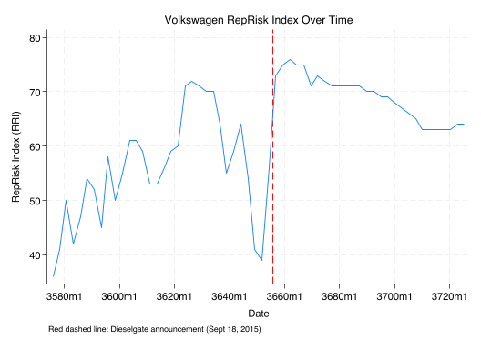

### Test: Section 1 Complete

```
✅ Section 1 tests passed
 - 60 firms in sample (VW group dropped)
 - Post variable created
 - Panel structure declared
 - Pre-treatment obs: 1920, Post-treatment obs: 1680
```

## Section 2: Summary Statistics by Group-Time

The essence of DiD is comparing changes over time between treatment and control groups. In this section, we'll create a 2×2 table of means and manually calculate the DiD estimator.

### Task 2.1: Create 2×2 Table of Means

Calculate the mean `current_RRI` for each combination of `german` (treatment) and `post` (time period). This gives us the four cell means needed for the DiD calculation.

[figure not shown]

Stata Tip

Use `table rowvar colvar, stat(mean outcome)` to create a table of means by group.

```
------------------------------------------------------------------
                                |    Post-treatment (Sept 2015+)
                                |          0          1      Total
--------------------------------+---------------------------------
german                          |
  0                             |
    Mean                        |      14.56      18.18      16.25
    Standard deviation          |      18.12      19.06      18.65
    Number of nonmissing values |    1824.00    1596.00    3420.00
  1                             |
    Mean                        |      52.70      61.12      56.63
    Standard deviation          |      11.15       9.01      11.02
    Number of nonmissing values |      96.00      84.00     180.00
  Total                         |
    Mean                        |      16.47      20.33      18.27
    Standard deviation          |      19.67      20.90      20.34
    Number of nonmissing values |    1920.00    1680.00    3600.00
------------------------------------------------------------------
```

### Task 2.2: Calculate DiD "By Hand"

Calculate the difference-in-differences estimator manually using the four cell means:

$$\tau_{DiD} = (\bar{Y}_{treat,post} - \bar{Y}_{treat,pre}) - (\bar{Y}_{control,post} - \bar{Y}_{control,pre})$$

Store the result in a local macro and display it. This manual calculation should match the regression coefficient in Section 4.

[figure not shown]

Stata Tip

Use `summarize var if condition` followed by `local mean = r(mean)` to calculate and store conditional means.

```
==== Difference-in-Differences Calculation ====


German firms (treated):
 Post:  61.12
 Pre:  52.70
 Diff:   8.42


Non-German firms (control):
 Post:  18.18
 Pre:  14.56
 Diff:   3.62


DiD Estimate:   4.80
==============================================
✅ DiD calculated manually
```

### Test: Section 2 Complete

```
✅ Section 2 tests passed
 - 2x2 means table created
 - Manual DiD estimate:   4.80
```

## Section 3: Parallel Trends Visualization

The key identifying assumption for DiD is **parallel trends**: in the absence of treatment, treated and control groups would have followed similar trajectories. While we cannot directly test this (it's about a counterfactual), we can visually inspect whether the groups moved together *before* the treatment.

### Task 3.1: Calculate Group Means Over Time

First, collapse the data to calculate the mean `current_RRI` for each `german` × `date` combination. We'll use `preserve` and `restore` to avoid losing the original data.

[figure not shown]

Stata Tip

- `preserve` — Save the current dataset state
- `collapse (mean) var, by(groupvars)` — Collapse to group means
- `restore` — Return to the original dataset

```
(Note: Below code run with echo to enable preserve/restore functionality.)

. preserve

. collapse (mean) mean_rri = current_RRI, by(german date)

. twoway (line mean_rri date if german == 1, lcolor(purple) lwidth(medium)) (li
> ne mean_rri date if german == 0, lcolor(gray) lwidth(medium)), title("Paralle
> l Trends: RepRisk Index by Treatment Group", size(medium)) xtitle("Date") yti
> tle("Mean RepRisk Index (RRI)") xline(`=mdy(9,18,2015)', lcolor(red) lpattern
> (dash)) legend(order(1 "German (treated)" 2 "Non-German (control)") rows(1) p
> osition(6)) note("Red dashed line: Dieselgate announcement (Sept 18, 2015)")
> name(parallel_trends, replace)

. graph export "$figures/parallel_trends.png", replace width(1200)
file /Users/casparm4/Github/rsm-data-analytics-in-finance-private/private/assig
> nments/04-assignment/output/figures/parallel_trends.png written in PNG format

. display "✅ Parallel trends plot saved"
✅ Parallel trends plot saved

. restore

.
```

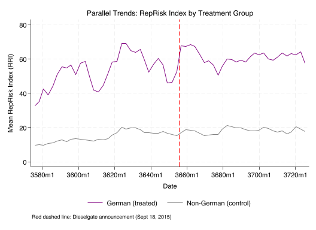

### Test: Section 3 Complete

```
✅ Section 3 tests passed
 - Parallel trends plot created
```

## Section 4: Canonical DiD Regression

Now let's estimate the canonical DiD regression. The model includes the treatment indicator (`german`), the post-treatment indicator (`post`), and their interaction (`german × post`). The coefficient on the interaction is the DiD estimate.

ℹ️ Background: Canonical DiD Regression

The canonical DiD regression model is:  
`Yit = β₀ + β₁ × Germani + β₂ × Postt + β₃ × (Germani × Postt) + εit`  
Where:

- **β₀**: Mean outcome for control group in pre-period
- **β₁**: Baseline difference between treatment and control groups (pre-period)
- **β₂**: Time trend common to both groups
- **β₃**: *The DiD estimate* — differential change for treated group

### Task 4.1: Create the Interaction Term

Create a new variable `treated_post` that equals `german × post`. This is the DiD interaction term.

[figure not shown]

Stata Tip

Use `gen treated_post = german * post` to create the interaction term.

```
    Means, Standard Deviations and Frequencies of German × Post (DiD)

           |   Post-treatment
           |    (Sept 2015+)
    german |         0          1 |     Total
-----------+----------------------+----------
         0 |         0          0 |         0
           |         0          0 |         0
           |      1824       1596 |      3420
-----------+----------------------+----------
         1 |         0          1 | .46666667
           |         0          0 | .50027925
           |        96         84 |       180
-----------+----------------------+----------
     Total |         0        .05 | .02333333
           |         0  .21800984 | .15098086
           |      1920       1680 |      3600
✅ Interaction term created
```

### Task 4.2: Estimate the Canonical DiD Regression

Estimate the regression: `current_RRI = β₀ + β₁×german + β₂×post + β₃×treated_post + ε`

Use robust standard errors, i.e., add the `, r` option.

Store the estimates as `did1` for later comparison.

**Questions to consider**:

- What is the coefficient on `treated_post`? Is it statistically significant?
- Does it match your manual DiD calculation from Section 2?
- What does this coefficient mean economically (in terms of RepRisk Index points)?

```
Linear regression                               Number of obs     =      3,600
                                                F(3, 3596)        =     900.76
                                                Prob > F          =     0.0000
                                                R-squared         =     0.1968
                                                Root MSE          =     18.238

------------------------------------------------------------------------------
             |               Robust
 current_RRI | Coefficient  std. err.      t    P>|t|     [95% conf. interval]
-------------+----------------------------------------------------------------
      german |   38.13322   1.209446    31.53   0.000     35.76195    40.50449
        post |   3.619518   .6385266     5.67   0.000     2.367607    4.871428
treated_post |   4.801613   1.626815     2.95   0.003     1.612041    7.991185
       _cons |   14.56469   .4243336    34.32   0.000     13.73273    15.39665
------------------------------------------------------------------------------


Manual DiD estimate:   4.80
Regression DiD estimate:   4.80
✅ Canonical DiD regression estimated
```

### Test: Section 4 Complete

```
✅ Section 4 tests passed
 - Interaction term created
 - DiD coefficient is positive (as expected)
 - Regression matches manual calculation
```

## Section 5: Add Control Variables

Adding time-varying control variables can improve precision and address potential omitted variable bias. However, controls must be "good" controls — variables that affect the outcome but are not themselves affected by treatment.

### Task 5.1: DiD Regression with Controls

Add the following control variables to the regression: `log_sale` (firm size), `leverage`, and `roa` (profitability).

Add robust standard errors using the `, r` option.

Store the estimates as `did2`.

**Question**: Did the DiD coefficient change much after adding controls? What does this tell us?

⚠️ Important

Be cautious about which controls to include. "Bad controls" — variables that are themselves affected by treatment — can introduce bias. For example, if Dieselgate affected a firm's profitability, controlling for ROA could absorb part of the treatment effect.

```
Linear regression                               Number of obs     =      3,600
                                                F(6, 3593)        =     872.81
                                                Prob > F          =     0.0000
                                                R-squared         =     0.4507
                                                Root MSE          =     15.089

------------------------------------------------------------------------------
             |               Robust
 current_RRI | Coefficient  std. err.      t    P>|t|     [95% conf. interval]
-------------+----------------------------------------------------------------
      german |   35.78826     1.1932    29.99   0.000     33.44885    38.12768
        post |   3.505634   .5317459     6.59   0.000      2.46308    4.548188
treated_post |   4.307353   1.510551     2.85   0.004      1.34573    7.268977
    log_sale |   3.598123   .0934028    38.52   0.000     3.414995    3.781251
    leverage |   2.400373   1.128868     2.13   0.034     .1870874    4.613659
         roa |  -33.82314   2.659785   -12.72   0.000    -39.03798    -28.6083
       _cons |  -24.07966   1.089107   -22.11   0.000    -26.21499   -21.94433
------------------------------------------------------------------------------
✅ DiD with controls estimated
```

### Task 5.2: Compare Models

Compare the two DiD models (with and without controls) using `estimates table`.

```
----------------------------------------------
    Variable |     did1            did2
-------------+--------------------------------
      german |  38.133224***    35.788262***
        post |  3.6195175***    3.5056342***
treated_post |  4.8016134**     4.3073531**
    log_sale |                  3.5981234***
    leverage |                  2.4003733*
         roa |                 -33.823141***
       _cons |  14.564693***   -24.079659***
-------------+--------------------------------
           N |       3600            3600
          r2 |  .19678931       .45069059
----------------------------------------------
      Legend: * p<0.05; ** p<0.01; *** p<0.001
```

### Test: Section 5 Complete

```
✅ Section 5 tests passed
 - Controls added to DiD regression
```

## Section 6: Two-Way Fixed Effects

The Two-Way Fixed Effects (TWFE) model is a generalization of DiD that includes firm fixed effects and time fixed effects. This absorbs all time-invariant firm characteristics and all firm-invariant time trends.

ℹ️ Background: Two-Way Fixed Effects

The TWFE model is:  
`Yit = αi + γt + β × (Germani × Postt) + εit`  
Where:

- **α<sub>i</sub>**: Firm fixed effects — absorb all time-invariant firm characteristics (including `german`)
- **γ<sub>t</sub>**: Time fixed effects — absorb all firm-invariant time trends (including `post`)
- **β**: The DiD estimate — identified only from the interaction term

**Key insight**: With firm and time fixed effects, the `german` and `post` main effects are absorbed (collinear with the fixed effects), so we only estimate the interaction term.

### Task 6.1: Estimate TWFE Model

Use `reghdfe` to estimate the two-way fixed effects model. Absorb firm fixed effects (`gvkey_num`) and time fixed effects (`date`).

Store the estimates as `did3`.

[figure not shown]

Stata Tip

The `reghdfe` command efficiently estimates models with high-dimensional fixed effects:  
`reghdfe outcome treatment_var, absorb(fe1 fe2) vce(robust)`

```
(MWFE estimator converged in 2 iterations)

HDFE Linear regression                            Number of obs   =      3,600
Absorbing 2 HDFE groups                           F(   1,   3480) =      15.60
                                                  Prob > F        =     0.0001
                                                  R-squared       =     0.8258
                                                  Adj R-squared   =     0.8199
                                                  Within R-sq.    =     0.0038
                                                  Root MSE        =     8.6335

------------------------------------------------------------------------------
             |               Robust
 current_RRI | Coefficient  std. err.      t    P>|t|     [95% conf. interval]
-------------+----------------------------------------------------------------
treated_post |   4.801613   1.215504     3.95   0.000      2.41844    7.184787
       _cons |   18.16046   .1478644   122.82   0.000     17.87055    18.45037
------------------------------------------------------------------------------

Absorbed degrees of freedom:
------------------------------------------------------+
  Absorbed FE | Categories  - Redundant  = Num. Coefs |
--------------+---------------------------------------|
    gvkey_num |        60           0          60     |
   year#month |        60           1          59     |
------------------------------------------------------+
✅ TWFE model estimated
Note: german and post are absorbed by firm and time fixed effects
```

### Test: Section 6 Complete

```
✅ Section 6 tests passed
 - TWFE model estimated with reghdfe
```

## Section 7: Clustered Standard Errors

With panel data, observations within the same firm are likely correlated over time. Clustering standard errors at the firm level accounts for this serial correlation.

⚠️ Important: Few Clusters Problem

Cluster-robust standard errors perform well asymptotically (many clusters), but can be unreliable with **few clusters**. In our case:

- Only **3 German firms** (VW, BMW, Mercedes-Benz) in the treated group
- Around **57 control firms**
- Total of ~60 clusters

With few treated clusters, clustered standard errors may be *too small*, leading to over-rejection. Keep this limitation in mind when interpreting results.

### Task 7.1: TWFE with Clustered Standard Errors

Re-estimate the TWFE model with standard errors clustered at the firm level.

Store the estimates as `did4`.

[figure not shown]

Stata Tip

Use `vce(cluster gvkey_num)` to cluster standard errors at the firm level.

```
(MWFE estimator converged in 2 iterations)

HDFE Linear regression                            Number of obs   =      3,600
Absorbing 2 HDFE groups                           F(   1,     59) =       3.79
Statistics robust to heteroskedasticity           Prob > F        =     0.0563
                                                  R-squared       =     0.8258
                                                  Adj R-squared   =     0.8199
                                                  Within R-sq.    =     0.0038
Number of clusters (gvkey_num) =         60       Root MSE        =     8.6335

                             (Std. err. adjusted for 60 clusters in gvkey_num)
------------------------------------------------------------------------------
             |               Robust
 current_RRI | Coefficient  std. err.      t    P>|t|     [95% conf. interval]
-------------+----------------------------------------------------------------
treated_post |   4.801613   2.466501     1.95   0.056    -.1338435     9.73707
       _cons |   18.16046   .0575517   315.55   0.000      18.0453    18.27562
------------------------------------------------------------------------------

Absorbed degrees of freedom:
------------------------------------------------------+
  Absorbed FE | Categories  - Redundant  = Num. Coefs |
--------------+---------------------------------------|
    gvkey_num |        60          60           0    *|
   year#month |        60           1          59     |
------------------------------------------------------+
* = FE nested within cluster; treated as redundant for DoF computation
✅ TWFE with clustered SEs estimated
```

### Test: Section 7 Complete

```
✅ Section 7 tests passed
 - Clustered standard errors applied
```

## Section 8: Event Study Specification

An event study specification allows us to examine the dynamics of the treatment effect over time. Instead of a single `post` indicator, we interact treatment with time-relative-to-event dummies. This helps visualize whether:

1. The parallel trends assumption holds in the pre-period (coefficients should be near zero)
2. The treatment effect is immediate or gradual

### Task 8.1: Create Relative Time Variable

Create a variable `rel_time` that measures the number of months relative to the event (September 2015 = 0, the first post-treatment month). Negative values are pre-treatment, positive values are post-treatment.

[figure not shown]

Stata Tip

Use `mofd(date)` to convert a date to months since Jan 1960, then subtract the event month.

```
     Months |
relative to |
event (Sept |
  2015 = 0) |      Freq.     Percent        Cum.
------------+-----------------------------------
        -32 |         60        1.67        1.67
        -31 |         60        1.67        3.33
        -30 |         60        1.67        5.00
        -29 |         60        1.67        6.67
        -28 |         60        1.67        8.33
        -27 |         60        1.67       10.00
        -26 |         60        1.67       11.67
        -25 |         60        1.67       13.33
        -24 |         60        1.67       15.00
        -23 |         60        1.67       16.67
        -22 |         60        1.67       18.33
        -21 |         60        1.67       20.00
        -20 |         60        1.67       21.67
        -19 |         60        1.67       23.33
        -18 |         60        1.67       25.00
        -17 |         60        1.67       26.67
        -16 |         60        1.67       28.33
        -15 |         60        1.67       30.00
        -14 |         60        1.67       31.67
        -13 |         60        1.67       33.33
        -12 |         60        1.67       35.00
        -11 |         60        1.67       36.67
        -10 |         60        1.67       38.33
         -9 |         60        1.67       40.00
         -8 |         60        1.67       41.67
         -7 |         60        1.67       43.33
         -6 |         60        1.67       45.00
         -5 |         60        1.67       46.67
         -4 |         60        1.67       48.33
         -3 |         60        1.67       50.00
         -2 |         60        1.67       51.67
         -1 |         60        1.67       53.33
          0 |         60        1.67       55.00
          1 |         60        1.67       56.67
          2 |         60        1.67       58.33
```

[output cut: 13 more lines]

```
         16 |         60        1.67       81.67
         17 |         60        1.67       83.33
         18 |         60        1.67       85.00
         19 |         60        1.67       86.67
         20 |         60        1.67       88.33
         21 |         60        1.67       90.00
         22 |         60        1.67       91.67
         23 |         60        1.67       93.33
         24 |         60        1.67       95.00
         25 |         60        1.67       96.67
         26 |         60        1.67       98.33
         27 |         60        1.67      100.00
------------+-----------------------------------
      Total |      3,600      100.00
✅ Relative time variable created
```

### Task 8.2: Estimate Event Study Specification

Estimate an event study regression that interacts the `german` indicator with relative time dummies. Use `rel_time = -1` (August 2015, the last pre-treatment month) as the reference period.

Then create an event study plot using `coefplot`.

[figure not shown]

Stata Tip

Use `ib(-1).rel_time` to set rel_time = -1 as the base category, and `c.german#i.rel_time` for the interaction.

```
(Note: Below code run with echo to enable preserve/restore functionality.)

. gen rel_time_binned = rel_time

. replace rel_time_binned = -12 if rel_time < -12
(1,200 real changes made)

. replace rel_time_binned = 12 if rel_time > 12
(900 real changes made)

. gen rel_time_shifted = rel_time_binned + 13

. reghdfe current_RRI c.german#ib(12).rel_time_shifted, absorb(gvkey_num date)
> vce(cluster gvkey_num)
(MWFE estimator converged in 2 iterations)
note: 25.rel_time_shifted#c.german omitted because of collinearity

HDFE Linear regression                            Number of obs   =      3,600
Absorbing 2 HDFE groups                           F(  24,     59) =     171.82
Statistics robust to heteroskedasticity           Prob > F        =     0.0000
                                                  R-squared       =     0.8272
                                                  Adj R-squared   =     0.8201
                                                  Within R-sq.    =     0.0116
Number of clusters (gvkey_num) =         60       Root MSE        =     8.6283

                             (Std. err. adjusted for 60 clusters in gvkey_num)
------------------------------------------------------------------------------
             |               Robust
 current_RRI | Coefficient  std. err.      t    P>|t|     [95% conf. interval]
-------------+----------------------------------------------------------------
rel_time_s~d#|
    c.german |
          1  |  -5.155388   1.474523    -3.50   0.001    -8.105902   -2.204875
          2  |    2.77193   1.981815     1.40   0.167    -1.193673    6.737532
          3  |   1.438596   2.310226     0.62   0.536    -3.184155    6.061348
          4  |    4.45614   2.945462     1.51   0.136    -1.437716       10.35
          5  |  -.4385965    1.41894    -0.31   0.758    -3.277889    2.400696
          6  |  -7.403509   3.497139    -2.12   0.038    -14.40127   -.4057492
          7  |  -2.701754    3.29291    -0.82   0.415    -9.290853    3.887344
          8  |   1.175439    1.57676     0.75   0.459     -1.97965    4.330527
```

[output cut: 117 more lines]

```
> RRI") legend(off) caption("Reference period: t = -1 (August 2015). 95% CIs sh
> own." "Dashed vertical line marks first post-treatment month.") name(event_st
> udy, replace)

. graph export "$figures/event_study_plot.png", replace width(1200)
file /Users/casparm4/Github/rsm-data-analytics-in-finance-private/private/assig
> nments/04-assignment/output/figures/event_study_plot.png written in PNG forma
> t

. restore

. display "✅ Event study plot saved"
✅ Event study plot saved

.
```

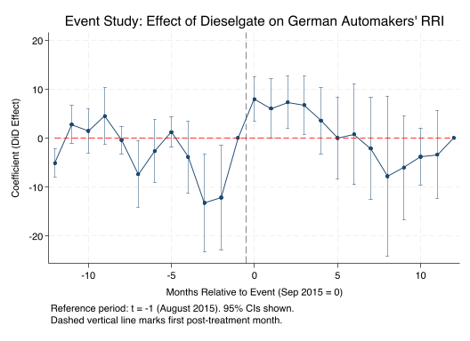

### Test: Section 8 Complete

```
✅ Section 8 tests passed
 - Relative time variable created
 - Event study plot saved
```

## Section 9: Regression Table

Create a publication-quality regression table showing the progression of specifications.

### Task 9.1: Export Regression Table

Use `esttab` to export all four DiD models to a LaTeX file. The table should show the progression from canonical DiD to TWFE with clustered standard errors.

[figure not shown]

Stata Tip: esttab Options

Key options:

- `se` — Show standard errors
- `star(* 0.10 ** 0.05 *** 0.01)` — Significance stars
- `stats(N r2)` — Include N and R²
- `mtitles()` — Column titles

```
(output written to /Users/casparm4/Github/rsm-data-analytics-in-finance-private
> /private/assignments/04-assignment/output/tables/did_regression_table.tex)
✅ Regression table exported: did_regression_table.tex
```

### Test: Section 9 Complete

```
✅ Section 9 tests passed
 - Regression table exported
```

## Section 10: Critical Evaluation

No research design is perfect. In this section, reflect on the limitations of our DiD analysis and what would strengthen our causal claims.

### Task 10.1: Discuss Limitations

In the markdown cell below, discuss at least **three limitations** of this DiD analysis. Consider:

1. **Parallel trends assumption**: Can we confidently say that German and non-German automakers would have followed similar RRI trends absent Dieselgate?
2. **Small number of treated units**: We have only 3 German firms in the treated group. What are the implications for inference?
3. **Other threats to identification**: Are there other events around September 2015 that might affect German automakers differently? (e.g., refugee crisis, other policy changes)
4. **Generalizability**: Can we generalize findings from the auto industry to other contexts?
5. **Measurement**: Is RepRisk a good measure of the "true" ESG risk impact of Dieselgate?

## Section 11: Extension — Spillover Analysis (Ungraded)

🚀 Above and Beyond

This section is **optional and ungraded**. It explores a more nuanced question: Was the reputational damage concentrated at Volkswagen (the scandal firm), or did it spill over to other German automakers (BMW, Mercedes-Benz)?  
This analysis helps distinguish between *direct effects* (VW was caught cheating) and *contagion/spillover effects* (guilt by national association).

### Extension 11.1: Create Treatment Subgroups

Create two new treatment indicators:

- `vw`: 1 for Volkswagen only (gvkey = "100737")
- `other_german`: 1 for other German firms (BMW, Mercedes-Benz)

```
                      |      Volkswagen
                 conm |         0          1 |     Total
----------------------+----------------------+----------
BAYERISCHE MOTOREN .. |        60          0 |        60
MERCEDES BENZ GROUP.. |        60          0 |        60
        VOLKSWAGEN AG |         0         60 |        60
----------------------+----------------------+----------
                Total |       120         60 |       180

                      |  Other German (BMW,
                      |       Mercedes)
                 conm |         0          1 |     Total
----------------------+----------------------+----------
BAYERISCHE MOTOREN .. |         0         60 |        60
MERCEDES BENZ GROUP.. |         0         60 |        60
        VOLKSWAGEN AG |        60          0 |        60
----------------------+----------------------+----------
                Total |        60        120 |       180
✅ Treatment subgroups created
```

### Extension 11.2: Separate DiD for VW vs Other German Firms

Run two separate DiD regressions:

1. VW vs. non-German control firms
2. Other German firms vs. non-German control firms

Compare the magnitudes. Is the effect larger for VW (the scandal firm)?

```
(MWFE estimator converged in 2 iterations)

HDFE Linear regression                            Number of obs   =      3,480
Absorbing 2 HDFE groups                           F(   1,     57) =      99.19
Statistics robust to heteroskedasticity           Prob > F        =     0.0000
                                                  R-squared       =     0.8100
                                                  Adj R-squared   =     0.8034
                                                  Within R-sq.    =     0.0056
Number of clusters (gvkey_num) =         58       Root MSE        =     8.6291

                             (Std. err. adjusted for 58 clusters in gvkey_num)
------------------------------------------------------------------------------
             |               Robust
 current_RRI | Coefficient  std. err.      t    P>|t|     [95% conf. interval]
-------------+----------------------------------------------------------------
     vw_post |   9.817982   .9857921     9.96   0.000     7.843968      11.792
       _cons |   16.96066   .0079317  2138.35   0.000     16.94478    16.97654
------------------------------------------------------------------------------

Absorbed degrees of freedom:
-----------------------------------------------------+
 Absorbed FE | Categories  - Redundant  = Num. Coefs |
-------------+---------------------------------------|
   gvkey_num |        58          58           0    *|
        date |        60           1          59     |
-----------------------------------------------------+
* = FE nested within cluster; treated as redundant for DoF computation
(MWFE estimator converged in 2 iterations)

HDFE Linear regression                            Number of obs   =      3,540
Absorbing 2 HDFE groups                           F(   1,     58) =       1.94
Statistics robust to heteroskedasticity           Prob > F        =     0.1695
                                                  R-squared       =     0.8125
                                                  Adj R-squared   =     0.8060
                                                  Within R-sq.    =     0.0006
Number of clusters (gvkey_num) =         59       Root MSE        =     8.6570

                             (Std. err. adjusted for 59 clusters in gvkey_num)
------------------------------------------------------------------------------
             |               Robust
```

[output cut: 21 more lines]

```
    Variable |    vw_only      other_germa~y
-------------+--------------------------------
     vw_post |  9.8179825***
other_germ~t |                  2.2934289
       _cons |   16.96066***    17.497901***
-------------+--------------------------------
           N |       3480            3540
          r2 |    .809981       .81249319
----------------------------------------------
      Legend: * p<0.05; ** p<0.01; *** p<0.001


Interpretation:
- VW coefficient: Direct effect on scandal firm
- Other German coefficient: Spillover/contagion effect on peers
```

### Extension 11.3: Interpretation

⚠️ Caveat: Very Small Sample

With only 1 firm in the "VW" treatment group and 2 firms in the "Other German" group, these estimates are essentially case studies rather than statistical inference. Interpret with extreme caution — the estimates are highly sensitive to firm-specific idiosyncrasies.

If VW shows a larger effect than other German firms, this suggests the reputational damage was concentrated at the scandal firm. If both show similar effects, it suggests broader contagion to the "German automotive" brand.

## References

- **Difference-in-Differences**: Angrist, J. D., & Pischke, J. S. (2009). *Mostly Harmless Econometrics*. Princeton University Press.
- **The Effect (Free Online Textbook)**: Huntington-Klein, N. (2021). [The Effect: An Introduction to Research Design and Causality](https://theeffectbook.net/)
- **Two-Way Fixed Effects**: Goodman-Bacon, A. (2021). "Difference-in-differences with variation in treatment timing," *Journal of Econometrics*.
- **RepRisk Methodology**: [RepRisk Research Methodology](https://www.reprisk.com/solutions/esg-due-diligence)
- **Dieselgate Timeline**: EPA Notice of Violation (September 18, 2015) - [EPA Press Release](https://www.epa.gov/newsreleases/epa-california-notify-volkswagen-clean-air-act-violations)
- **Stata Documentation**: [reghdfe](http://scorreia.com/software/reghdfe/), [coefplot](http://repec.sowi.unibe.ch/stata/coefplot/)

Data Analytics for Finance

BM17FI · Academic Year 2025–26

[figure not shown]

Created by: Caspar David Peter

© 2026 Rotterdam School of Management